# Research Project

Karim Abdel, Lorenzo Tarricone

5/1/2022

# Introduction and research question

Life-Expectancy has constantly increased over the last centuries, and it has never been so high as nowadays. Medicine has taken great strides forward, eradicating and finding cures for a lot of mortal diseases. Having said that, there are still other big challenges that we have to face in medicine and one of those is for sure cancer. [Cancer is a leading cause of death all over the world, accounting for almost 10 milion deaths in 2020](https://www.who.int/news-room/fact-sheets/detail/cancer). This is the reason why we thought that would be very interesting to analyze the principal factors that, according to state-of-the-art scientific research, cause this disease. We also wanted to divide these factors in some macro-groups of variables: environmental, life-style related and socio-economical/demographic.

Our analysis (purely statistical) aims to verify if it is indeed possible using data about the selected risk factors to predict the share of people with cancer in a given year and in a given country. Moreover, we tried to improve our all-inclusive model by finding out the best model out of the above mentioned factors.

# Dataset, Data Cleaning and Data Visualization

## Source

Our research started by searching out on some reliable websites what are the leading causes of cancer and dividing them into the macro-categories. To do that we adopted the [WHO official website](https://www.who.int/news-room/fact-sheets/detail/cancer) and we selected the following risk factors:

*ENVIRONMENTAL*: Air pollution *LIFE-STYLE RELATED*: Alcohol consumption, Tobacco consumption, Obesity *SOCIO-ECONOMICAL/DEMOGRAPHIC*: GDP, Share of old people

(IMPORTANT DISCLAMER: of course the factors defined under “Socio-Economical/Demographic” cannot be considered to **cause** cancer, but as we will see they turn out to be very useful to model cancer all over the world and over time)

## Description of the variables

We built our dataset selecting by merging different csv files all taken from the same source, that is [“Our world in data”](https://ourworldindata.org/). This is by itself collecting datasets from verified sources and the precise reference for each factor is given in the sitography at the end of the paper. Here we provide a complete description of the variable we decided to use in our model.

**Cancer**: Share of total population with any form of cancer, measured as the age-standardized percentage. This share has been age-standardized assuming a constant age structure to compare prevalence between countries and through time.

**Air_pollution**: Population-weighted average level of exposure to concentrations of suspended particles measuring less than 2.5 microns in diameter (PM2.5). Exposure is measured in micro grams of PM2.5 per cubic meter (µg/m³).

**Alcohol**: Average per capta consumption of alcoholic beverages, measured in kilograms per year. Data is based on per capta food supply at the consumer level, but does not account for food waste at the consumer level

**GDP per capta**: Measured in constant international-$

**Obesity**: Obesity is defined as having a body-mass index (BMI) equal to or greater than 30. BMI is a person’s weight in kilograms divided by his or her height in meters squared.

**Old age Dependency**: This is the ratio of the number of people older than 64 relative to the number of people in the working-age (15-64 years). Data are given as the proportion of dependents per 100 working-age population.

**Smoking**: Share of population who smoke every day.

## Constructing the table

We started by loading all the different csv files. Then we took the column we were interested in and we glued them together. After some other little manipulation (see the R code for that) here is how part of the final table looks like (the complete table with the N.A.s results in a dimension of 6468x11):

| Entity | Code | Year | Cancer | AirPoll | Alcool | GDP | Obesity | Age | Smoking | continent |
| --- | --- | --- | --- | --- | --- | --- | --- | --- | --- | --- |
| Afghanistan | AFG | 1990 | 0.4768669 | 65.486792 | 0.00 | NA | 1.3 | 4.5139024 | 10.8 | Asia |
| Afghanistan | AFG | 1991 | 0.4762576 | NA | 0.00 | NA | 1.4 | 4.5262761 | 10.9 | Asia |
| Afghanistan | AFG | 1992 | 0.4756493 | NA | 0.00 | NA | 1.5 | 4.5542630 | 11.0 | Asia |
| Afghanistan | AFG | 1993 | 0.4756404 | NA | 0.00 | NA | 1.5 | 4.6010208 | 11.1 | Asia |
| Afghanistan | AFG | 1994 | 0.4802807 | NA | 0.00 | NA | 1.6 | 4.6673234 | 11.2 | Asia |
| Afghanistan | AFG | 1995 | 0.4832778 | 65.179513 | 0.00 | NA | 1.7 | 4.7544226 | 11.3 | Asia |
| Afghanistan | AFG | 1996 | 0.4848112 | NA | 0.00 | NA | 1.8 | 4.7809252 | 11.4 | Asia |
| Afghanistan | AFG | 1997 | 0.4868637 | NA | 0.00 | NA | 1.9 | 4.7844437 | 11.6 | Asia |
| Afghanistan | AFG | 1998 | 0.4885085 | NA | 0.00 | NA | 2.1 | 4.7685362 | 11.7 | Asia |
| Afghanistan | AFG | 1999 | 0.4941185 | NA | 0.00 | NA | 2.2 | 4.7377444 | 11.8 | Asia |

[output cut: 6458 more lines]

## Data Visualization

Now we will proceed with some plotting. Again, for the detailed process for making this graphs please refer to the R script. You may also want to check our our file in Html format, in which we made some nice animation to be able to display the evolution in time of the variables.

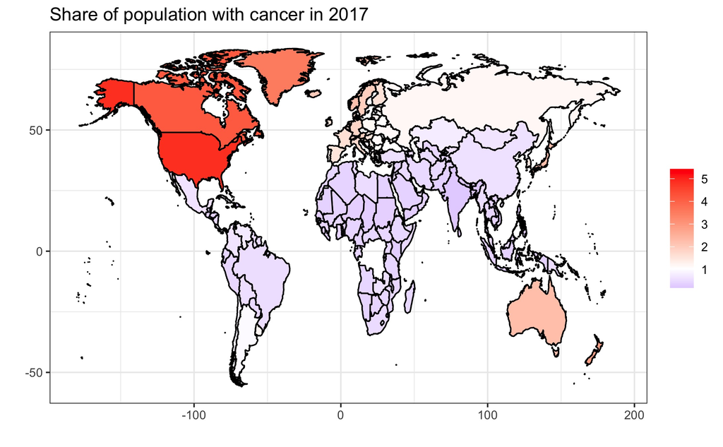

Now we are going to explore the dataset by plotting each selected factor against the Cancer one to start having an idea of some possible relation. Because we selected them as “risk factors” we would expect to see some positive correlation going on. To be consistent with what we have done above we again plot the graphs relative to the year 2017. We also used some libraries to make plots nicer by coloring the points according to the continent and by changing the size according to the population of the country. The result is the following:

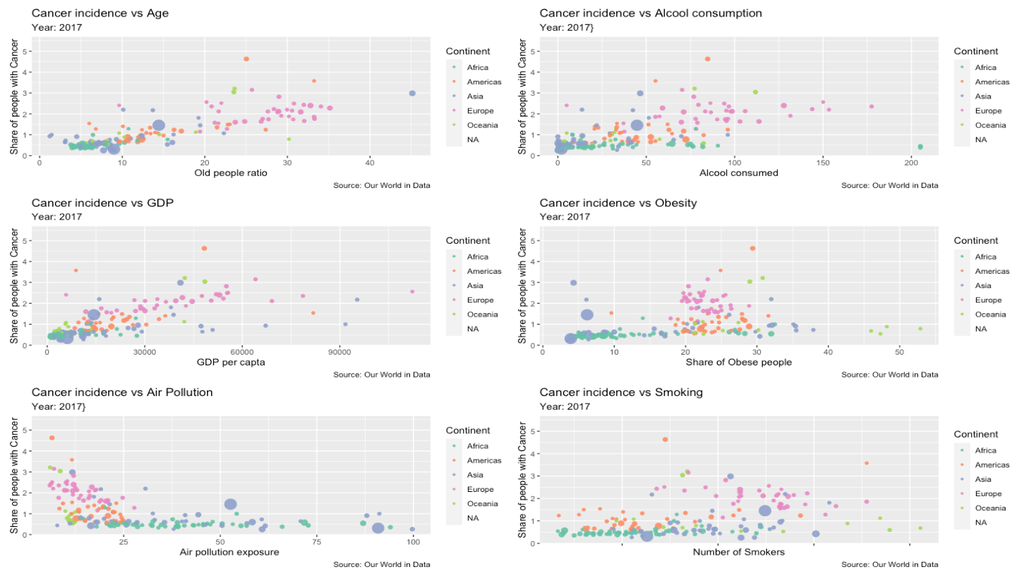

We also have some outliers, which are Canada and US (The two orange points that on each graph are above the others). Being cancer causes such a complicated and intricate thing, is actually quite difficult to really understand why exactly those two countries have such an high number of cases. We can suppose that these two countries perform a more intense screening activity, but this goes beyond the scope of this study. We will just delete these two countries from our data set. Having said that, the result that follow will be not significantly changed by this action.

# Multivariate Linear Regression

Now, let’s proceed with performing the actual multiple linear regression. After that, we want to see if the assumptions required to state the statistical significance are met: we’ll check for the normality and for the homoscedasticity of the residuals.

```
## -----------------------------------------------
##        Test             Statistic       pvalue
## -----------------------------------------------
## Shapiro-Wilk              0.722          0.0000
## Kolmogorov-Smirnov        0.1671         0.0000
## Cramer-von Mises         216.6397        0.0000
## Anderson-Darling         46.5541         0.0000
## -----------------------------------------------
```

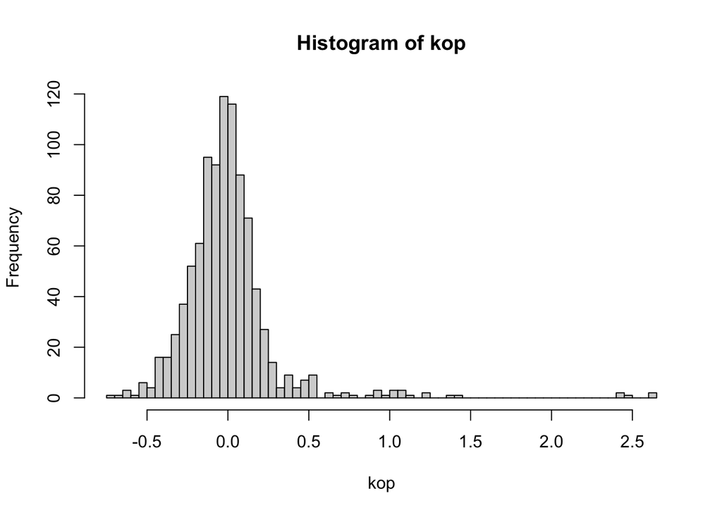

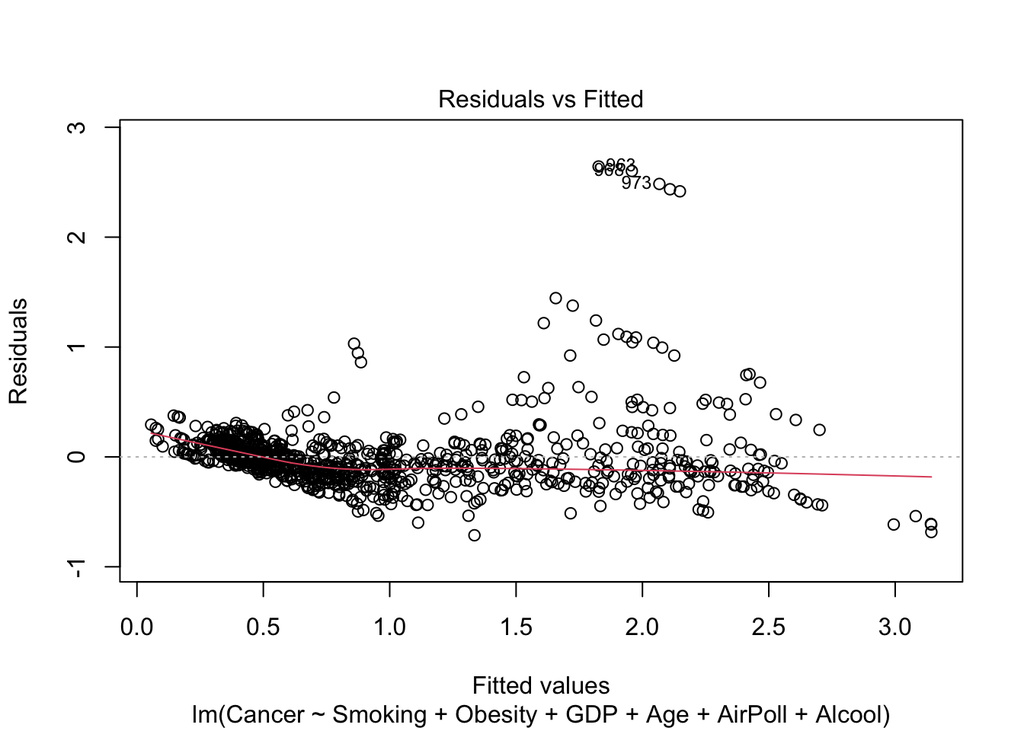

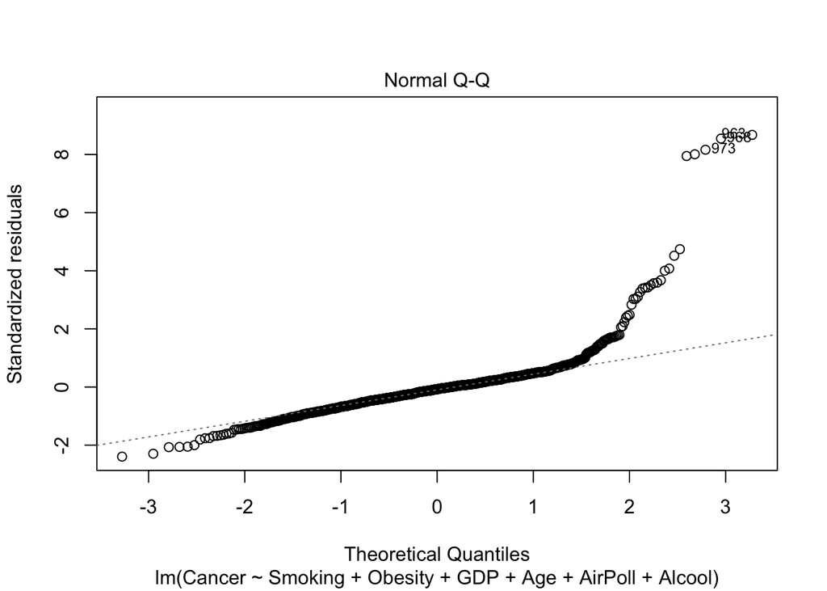

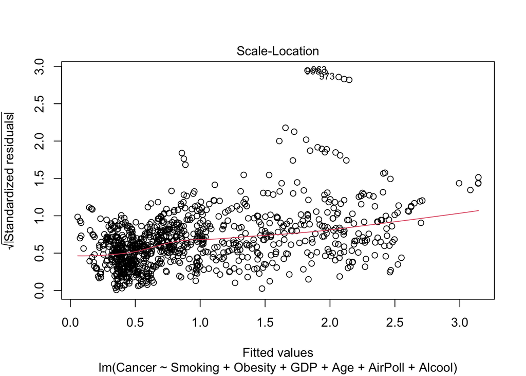

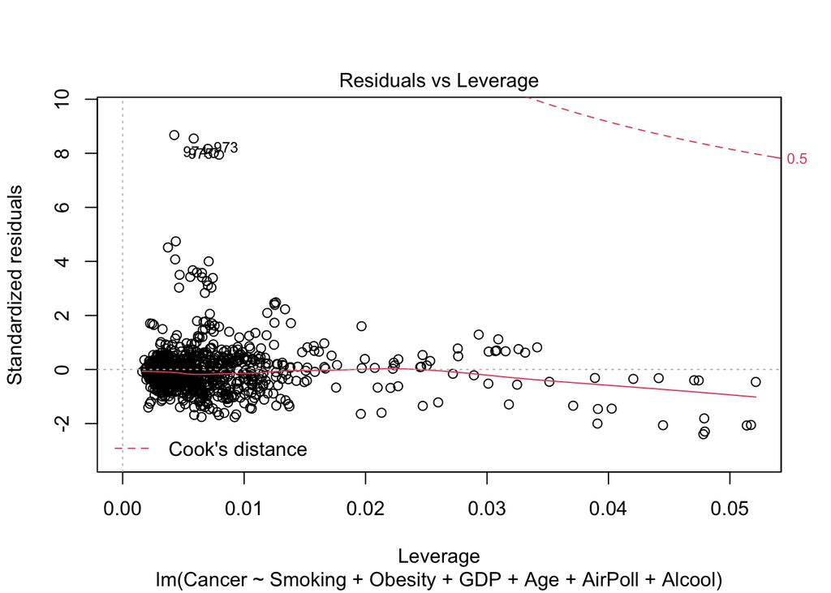

We now perform and interpret the result of the multiple linear regression itself.

```
##
## Call:
## lm(formula = Cancer ~ Smoking + Obesity + GDP + Age + AirPoll +
##     Alcool, data = data3)
##
## Residuals:
##      Min       1Q   Median       3Q      Max
## -0.71319 -0.14060 -0.02478  0.08123  2.64302
##
## Coefficients:
##               Estimate Std. Error t value Pr(>|t|)
## (Intercept)  2.020e-01  4.013e-02   5.035 5.74e-07 ***
## Smoking     -2.872e-03  1.371e-03  -2.095 0.036418 *
## Obesity      2.647e-03  1.414e-03   1.871 0.061588 .
## GDP          1.666e-05  9.009e-07  18.497  < 2e-16 ***
## Age          5.045e-02  2.250e-03  22.419  < 2e-16 ***
## AirPoll     -4.296e-03  6.737e-04  -6.377 2.83e-10 ***
## Alcool       1.150e-03  3.259e-04   3.528 0.000439 ***
## ---
## Signif. codes:  0 '***' 0.001 '**' 0.01 '*' 0.05 '.' 0.1 ' ' 1
##
## Residual standard error: 0.3053 on 941 degrees of freedom
## Multiple R-squared:  0.8243, Adjusted R-squared:  0.8232
## F-statistic:   736 on 6 and 941 DF,  p-value: < 2.2e-16
```

From just this result, we can see various things: the value of the Adjusted R-Squared is very satisfying and this model fits pretty well the data, telling us there is a quite good relationship with the covariates we indicated: our factors explain an 82% variance in the share of population with cancer! We are actually considering the Adjusted R-Squared since we are performing a multivariate linear regression, thus the number of factors we include in our model is relevant and we want to penalize bigger models. In fact we know that the value of R-Squared can just increase when adding more factors, even if those are completely random ones. In addition, all the variables seem to explain pretty well the share of cancer cases: almost all of the p-values are statistically significant! The only exception is given by the “Obesity” explanatory variable.

# Model Selection (Testing)

Now that we discussed the linear model and the underlying characteristics, we want to do some basic model selection to see if there are other models (possibly simpler) that are able to explain the dependent variable well enough. To do that we will leverage on two different approach to model selection. The first is the one provided by testing and the other the one provided by information theory. We will compare the results and see whether they coincide or not.

We start by importing the data we will need for the model selection and loading some useful libraries. We will then create our linear model using all the covariates and the dataset without the missing values (we will use the same model obtained above with the regression)

```
##
## Call:
## lm(formula = Cancer ~ Smoking + Obesity + GDP + Age + AirPoll +
##     Alcool, data = data3)
##
## Residuals:
##      Min       1Q   Median       3Q      Max
## -0.71319 -0.14060 -0.02478  0.08123  2.64302
##
## Coefficients:
##               Estimate Std. Error t value Pr(>|t|)
## (Intercept)  2.020e-01  4.013e-02   5.035 5.74e-07 ***
## Smoking     -2.872e-03  1.371e-03  -2.095 0.036418 *
## Obesity      2.647e-03  1.414e-03   1.871 0.061588 .
## GDP          1.666e-05  9.009e-07  18.497  < 2e-16 ***
## Age          5.045e-02  2.250e-03  22.419  < 2e-16 ***
## AirPoll     -4.296e-03  6.737e-04  -6.377 2.83e-10 ***
## Alcool       1.150e-03  3.259e-04   3.528 0.000439 ***
## ---
## Signif. codes:  0 '***' 0.001 '**' 0.01 '*' 0.05 '.' 0.1 ' ' 1
##
## Residual standard error: 0.3053 on 941 degrees of freedom
## Multiple R-squared:  0.8243, Adjusted R-squared:  0.8232
## F-statistic:   736 on 6 and 941 DF,  p-value: < 2.2e-16
```

We begin by trying three different testing methods, called respectively “Step-up/Forward”, “Step-down/Backward” and “Step-both”. The fist acts in a dual way with respect to the second and the last is in a way able to overcome the downsides of the first two models (I’ll explain later what I mean by that). Without entering too much into the details this greedy methodology starts with no(all) predictors in the model and iteratively add(subtract) the one that is more statistically significant in contributing to the model. The procedure automatically stops when no other variables can be added to gain statistical significance. In practice what we do at each step is to perform an F-test (that reduces to a t-test) for each candidate variable and see which one has the lowest p-value (if there is one). In this setting we kept a significance level of 0.05 both for entering and for exiting the model.

The Step-up method yields:

```
##
##                             Selection Summary
## --------------------------------------------------------------------------
##         Variable                  Adj.
## Step    Entered     R-Square    R-Square      C(p)        AIC        RMSE
## --------------------------------------------------------------------------
##    1    Age           0.7156      0.7153    579.6198    896.8510    0.3875
##    2    GDP           0.8108      0.8104     71.6307    512.4933    0.3162
##    3    AirPoll       0.8210      0.8204     19.0720    462.0425    0.3078
##    4    Alcool        0.8231      0.8224      9.5664    452.6010    0.3061
## --------------------------------------------------------------------------
```

The selection led us to add to the model the “Age”, “GDP”, “Airpoll” and “Alcool”. *BAAAM* We now try the symmetrical method,

The Step-down method yields:

```
##
##
##                           Elimination Summary
## ------------------------------------------------------------------------
##         Variable                  Adj.
## Step    Removed     R-Square    R-Square     C(p)       AIC        RMSE
## ------------------------------------------------------------------------
##    1    Obesity       0.8237      0.8227    8.5024    451.5307    0.3057
##    2    Smoking       0.8231      0.8224    9.5664    452.6010    0.3061
## ------------------------------------------------------------------------
```

As you can see we got the same result here: we rejected the “Obesity” and the “Smoking” cofactor. Notice that even if the methods seem completely specular, it’s not granted that they’ll lead us to the same outcome. *DOUBLE BAAAM*

To do one last cross-check using testing methods we use a mixed method to allow variables that were added in previous steps to be excluded in succeeding steps (this wasn’t allowed in the simple forward/step-up method)

The “Step-both” method yields:

```
##
##                               Stepwise Selection Summary
## --------------------------------------------------------------------------------------
##                      Added/                   Adj.
## Step    Variable    Removed     R-Square    R-Square      C(p)        AIC        RMSE
## --------------------------------------------------------------------------------------
##    1      Age       addition       0.716       0.715    579.6200    896.8510    0.3875
##    2      GDP       addition       0.811       0.810     71.6310    512.4933    0.3162
##    3    AirPoll     addition       0.821       0.820     19.0720    462.0425    0.3078
##    4     Alcool     addition       0.823       0.822      9.5660    452.6010    0.3061
## --------------------------------------------------------------------------------------
```

But this again yields the same result as the one we got with the step forward method. As well as before, the fact that we obtained the same result with all the three approaches is a very likable. *TRIPLE BAAAAM* This seems to suggest a model of four variables that is cutting “Smoking” and “Obesity”, given that these two risk factor are removed by all three of our greedy methods.

We now try all together different methods based on Information criterion. These work in such a way that they penalize big models that otherwise would be selected by methods such as LSE and MLE. The math underneath this approach is absolutely non trivial and explaining it goes beyond the scope of this research. To implement this we will use the function “best_subset” That is returning the best model containing from one to six covariates. We therefore limit our comparison to the comparison between all the best subsets models that we can have.

|  | mindex | n | predictors | rsquare | adjr | predrsq | cp | aic | sbic | sbc | msep | fpe | apc | hsp |
| --- | --- | --- | --- | --- | --- | --- | --- | --- | --- | --- | --- | --- | --- | --- |
| 4 | 1 | 1 | Age | 0.7155736 | 0.7152729 | 0.7141518 | 579.619812 | 896.8510 | -1795.253 | 911.4140 | 142.35239 | 0.15047754 | 0.2856290 | 1.589003e-04 |
| 16 | 2 | 2 | GDP Age | 0.8107774 | 0.8103769 | 0.8085958 | 71.630698 | 512.4933 | -2178.211 | 531.9107 | 94.80423 | 0.10032082 | 0.1904240 | 1.059368e-04 |
| 38 | 3 | 3 | GDP Age AirPoll | 0.8209623 | 0.8203933 | 0.8187773 | 19.071953 | 462.0425 | -2228.358 | 486.3143 | 89.79651 | 0.09512151 | 0.1805550 | 1.004473e-04 |
| 56 | 4 | 4 | GDP Age AirPoll Alcool | 0.8231101 | 0.8223598 | 0.8206752 | 9.566408 | 452.6010 | -2237.702 | 481.7271 | 88.81344 | 0.09417887 | 0.1787657 | 9.945303e-05 |
| 61 | 5 | 5 | Smoking GDP Age AirPoll Alcool | 0.8236821 | 0.8227462 | 0.8209354 | 8.502448 | 451.5307 | -2238.732 | 485.5112 | 88.62034 | 0.09407260 | 0.1785640 | 9.934214e-05 |
| 63 | 6 | 6 | Smoking Obesity GDP Age AirPoll Alcool | 0.8243359 | 0.8232159 | 0.8212494 | 7.000000 | 450.0087 | -2240.195 | 488.8436 | 88.38564 | 0.09392171 | 0.1782776 | 9.918434e-05 |

This seems to suggest a different result. All of these criteria are suggesting that the best model is the one with all six explanatory variables except for the SBC method, which again is suggesting the model with four variables as before. This discrepancy can be explained by the fact that, at least for the Akaike Information Criteria, that we studied in class, the underlying constant C could dominate. This method is in fact more suitable for models with different dimensions |d|. (Notice also the difference in AIC is very low: ($\Delta AIC = 2.59$ ). With small models AIC can easily prefer the complete model as the gain in “explained variance” obtained by adding a variable is more than the penalty introduced by that extra parameter.

We conclude this section by saying that the best model after this analysis is the one with four explanatory variables, obtained with the three step-wise method.